# PCA的R实现和运用

### R中PCA的实现

在[一文缕清PCA](http://haoeric.com/statistics%20and%20algorithms/2016/09/02/understand-pca/)中，我们缕清楚了PCA的原理和计算方法，那么这里就动手用R来实践下PCA。

```r
pca <- function(data){
    data <- as.matrix(data)
    ## 将每一列的平均值变为0
    data <- apply(data, 2, function(x) {x - mean(x)})
    ## 计算协方差矩阵
    corMatrix <- t(data) %*% data / nrow(data)
    ## 用'base'包中的eigen函数计算协方差矩阵的特征值的特征向量
    eigenRes <- eigen(corMatrix)
    eigenValues <- eigenRes$values
    eigenVectors <- eigenRes$vectors
    ## 用特征向量构成的矩阵转化原数据
    dataTransformed <- data %*% eigenRes$vectors
    ## 用列表结构返回数据
    return(list("eigenValues" = eigenValues,
                "eigenVectors" = eigenVectors,
                "dataTransformed" = dataTransformed))
}
```

在R的`stats`包中有两个函数来计算PCA：`prcomp`和`princomp`。其源代码可以通过`getAnywhere(prcomp.default)`和`getAnywhere(princomp.default)`获取。他俩的差别只是在计算方法上，`prcomp`使用的是SVD，而`princomp`使用的是和上面类似的求特征值和特征向量的方法。看看他两的文档：

> **prcomp**: The calculation is done by a singular value decomposition of the (centered and possibly scaled) data matrix, not by using `eigen` on the covariance matrix. This is generally the preferred method for numerical accuracy. The print method for these objects prints the results in a nice format and the plot method produces a scree plot. Unlike `princomp`, variances are computed with the usual divisor N - 1.

> **princomp**: The calculation is done using `eigen` on the correlation or covariance matrix, as determined by `cor`. ‘princomp’ only handles so-called R-mode PCA, that is feature extraction of variables. If a data matrix is supplied (possibly via a formula) it is required that there are at least as many units as variables. For Q-mode PCA use ‘prcomp’.

> Principal component analysis is underspecified if you have fewer samples than data point. Every data point will be it’s own principal component. For PCA to work, the number of instances should be significantly larger than the number of dimensions. Simply speaking you can look at the problems like this: If you have n dimensions, you can encode up to n+1 instances using vectors that are all 0 or that have at most one 1. And this is optimal, so PCA will do this! But it is not very helpful. – Explained from [stackoverflow](http://stackoverflow.com/questions/5686940/r-princomp-can-only-be-used-with-more-units-than-variables)

## 不同方法计算PCA的差别

```r
## 使用数据iris
data <- iris[ ,1:4]
row.names(data) <- paste0(iris[,5], "_", 1:nrow(data))
head(data)
```

```
##          Sepal.Length Sepal.Width Petal.Length Petal.Width
## setosa_1          5.1         3.5          1.4         0.2
## setosa_2          4.9         3.0          1.4         0.2
## setosa_3          4.7         3.2          1.3         0.2
## setosa_4          4.6         3.1          1.5         0.2
## setosa_5          5.0         3.6          1.4         0.2
## setosa_6          5.4         3.9          1.7         0.4
```

```r
pca_res1 <- pca(data)
pca_res2 <- prcomp(data)
pca_res3 <- princomp(data)
```

看看返回结果的差别：

```r
str(pca_res1)
```

```
## List of 3
##  $ eigenValues    : num [1:4] 4.2001 0.2411 0.0777 0.0237
##  $ eigenVectors   : num [1:4, 1:4] 0.3614 -0.0845 0.8567 0.3583 0.6566 ...
##  $ dataTransformed: num [1:150, 1:4] -2.68 -2.71 -2.89 -2.75 -2.73 ...
##   ..- attr(*, "dimnames")=List of 2
##   .. ..$ : chr [1:150] "setosa_1" "setosa_2" "setosa_3" "setosa_4" ...
##   .. ..$ : NULL
```

```r
str(pca_res2)
```

```
## List of 5
##  $ sdev    : num [1:4] 2.056 0.493 0.28 0.154
##  $ rotation: num [1:4, 1:4] 0.3614 -0.0845 0.8567 0.3583 -0.6566 ...
##   ..- attr(*, "dimnames")=List of 2
##   .. ..$ : chr [1:4] "Sepal.Length" "Sepal.Width" "Petal.Length" "Petal.Width"
##   .. ..$ : chr [1:4] "PC1" "PC2" "PC3" "PC4"
##  $ center  : Named num [1:4] 5.84 3.06 3.76 1.2
##   ..- attr(*, "names")= chr [1:4] "Sepal.Length" "Sepal.Width" "Petal.Length" "Petal.Width"
##  $ scale   : logi FALSE
##  $ x       : num [1:150, 1:4] -2.68 -2.71 -2.89 -2.75 -2.73 ...
##   ..- attr(*, "dimnames")=List of 2
##   .. ..$ : chr [1:150] "setosa_1" "setosa_2" "setosa_3" "setosa_4" ...
##   .. ..$ : chr [1:4] "PC1" "PC2" "PC3" "PC4"
##  - attr(*, "class")= chr "prcomp"
```

```r
str(pca_res3)
```

```
## List of 7
##  $ sdev    : Named num [1:4] 2.049 0.491 0.279 0.154
##   ..- attr(*, "names")= chr [1:4] "Comp.1" "Comp.2" "Comp.3" "Comp.4"
##  $ loadings: loadings [1:4, 1:4] 0.3614 -0.0845 0.8567 0.3583 -0.6566 ...
##   ..- attr(*, "dimnames")=List of 2
##   .. ..$ : chr [1:4] "Sepal.Length" "Sepal.Width" "Petal.Length" "Petal.Width"
##   .. ..$ : chr [1:4] "Comp.1" "Comp.2" "Comp.3" "Comp.4"
##  $ center  : Named num [1:4] 5.84 3.06 3.76 1.2
##   ..- attr(*, "names")= chr [1:4] "Sepal.Length" "Sepal.Width" "Petal.Length" "Petal.Width"
##  $ scale   : Named num [1:4] 1 1 1 1
##   ..- attr(*, "names")= chr [1:4] "Sepal.Length" "Sepal.Width" "Petal.Length" "Petal.Width"
##  $ n.obs   : int 150
##  $ scores  : num [1:150, 1:4] -2.68 -2.71 -2.89 -2.75 -2.73 ...
##   ..- attr(*, "dimnames")=List of 2
##   .. ..$ : chr [1:150] "setosa_1" "setosa_2" "setosa_3" "setosa_4" ...
##   .. ..$ : chr [1:4] "Comp.1" "Comp.2" "Comp.3" "Comp.4"
##  $ call    : language princomp(x = data)
##  - attr(*, "class")= chr "princomp"
```

看看特征值，会发现`pca_res1`中对应的特征值其实是变换后矩阵各列向量的方差。

```r
sqrt(pca_res1$eigenValues)
```

```
## [1] 2.0494032 0.4909714 0.2787259 0.1538707
```

```r
pca_res2$sdev
```

```
## [1] 2.0562689 0.4926162 0.2796596 0.1543862
```

```r
pca_res3$sdev
```

```
##    Comp.1    Comp.2    Comp.3    Comp.4
## 2.0494032 0.4909714 0.2787259 0.1538707
```

这里`pca_res2`和`pca_res3`中`sdev`的反差是由自由度使用的不用而造成的，正如上面`prcomp`中文档所表述的。

在来看看特征向量：

```r
pca_res1$eigenVectors
```

```
##             [,1]        [,2]        [,3]       [,4]
## [1,]  0.36138659  0.65658877 -0.58202985  0.3154872
## [2,] -0.08452251  0.73016143  0.59791083 -0.3197231
## [3,]  0.85667061 -0.17337266  0.07623608 -0.4798390
## [4,]  0.35828920 -0.07548102  0.54583143  0.7536574
```

```r
pca_res2$rotation
```

```
##                      PC1         PC2         PC3        PC4
## Sepal.Length  0.36138659 -0.65658877  0.58202985  0.3154872
## Sepal.Width  -0.08452251 -0.73016143 -0.59791083 -0.3197231
## Petal.Length  0.85667061  0.17337266 -0.07623608 -0.4798390
## Petal.Width   0.35828920  0.07548102 -0.54583143  0.7536574
```

```r
unclass(pca_res3$loadings)
```

```
##                   Comp.1      Comp.2      Comp.3     Comp.4
## Sepal.Length  0.36138659 -0.65658877 -0.58202985  0.3154872
## Sepal.Width  -0.08452251 -0.73016143  0.59791083 -0.3197231
## Petal.Length  0.85667061  0.17337266  0.07623608 -0.4798390
## Petal.Width   0.35828920  0.07548102  0.54583143  0.7536574
```

这里只是对特征向量的叫法不同，`prcomp`中叫`rotation`，`princomp`中叫做`loadings`。其中正负的差别不会影响整体的结构。

再来看看变化后的矩阵：

```r
head(pca_res1$dataTransformed)
```

```
##               [,1]       [,2]        [,3]         [,4]
## setosa_1 -2.684126  0.3193972 -0.02791483  0.002262437
## setosa_2 -2.714142 -0.1770012 -0.21046427  0.099026550
## setosa_3 -2.888991 -0.1449494  0.01790026  0.019968390
## setosa_4 -2.745343 -0.3182990  0.03155937 -0.075575817
## setosa_5 -2.728717  0.3267545  0.09007924 -0.061258593
## setosa_6 -2.280860  0.7413304  0.16867766 -0.024200858
```

```r
head(pca_res2$x)
```

```
##                PC1        PC2         PC3          PC4
## setosa_1 -2.684126 -0.3193972  0.02791483  0.002262437
## setosa_2 -2.714142  0.1770012  0.21046427  0.099026550
## setosa_3 -2.888991  0.1449494 -0.01790026  0.019968390
## setosa_4 -2.745343  0.3182990 -0.03155937 -0.075575817
## setosa_5 -2.728717 -0.3267545 -0.09007924 -0.061258593
## setosa_6 -2.280860 -0.7413304 -0.16867766 -0.024200858
```

```r
head(pca_res3$scores)
```

```
##             Comp.1     Comp.2      Comp.3       Comp.4
## setosa_1 -2.684126 -0.3193972 -0.02791483  0.002262437
## setosa_2 -2.714142  0.1770012 -0.21046427  0.099026550
## setosa_3 -2.888991  0.1449494  0.01790026  0.019968390
## setosa_4 -2.745343  0.3182990  0.03155937 -0.075575817
## setosa_5 -2.728717 -0.3267545  0.09007924 -0.061258593
## setosa_6 -2.280860 -0.7413304  0.16867766 -0.024200858
```

同样，这里除了正负号的差别，只是叫法的不同。

### PCA结果的运用

这里我们来看看最常用的`prcomp`函数结果的运用。

1. 主成分得分

```r
summary(pca_res2)
```

```
## Importance of components:
##                           PC1     PC2    PC3     PC4
## Standard deviation     2.0563 0.49262 0.2797 0.15439
## Proportion of Variance 0.9246 0.05307 0.0171 0.00521
## Cumulative Proportion  0.9246 0.97769 0.9948 1.00000
```

2. 碎石图

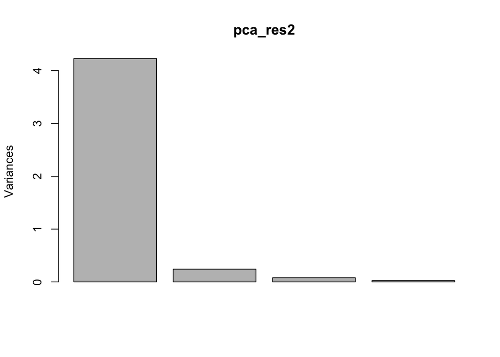

```r
plot(pca_res2)
```

这里的柱状图表示的特征值的大小，也就是方差，注意不是返回值`sdev`标准差。

automatical selection of main PCs by elbow detection

```r
elbow_detection <- function(scores, if_plot = FALSE){

    num_scores <- length(scores)
    if(num_scores < 2){
        stop("Input scores must be a vector with length more than 1!")
    }
    scores <- data.frame('id'=seq_len(num_scores), 'value'=scores)
    sorted_scores <- scores[order(scores$value, decreasing = T), ]

    ## use distance to diagonal line to determine the elbow point
    xy_coordinates <- cbind('x'=seq_len(num_scores), 'y'=sorted_scores$value)
    start_point <- xy_coordinates[1, ]
    end_point <- xy_coordinates[num_scores, ]
    x1 <- start_point[1]; x2 <- end_point[1]
    y1 <- start_point[2]; y2 <- end_point[2]
    a <- y1-y2; b <- x2-x1; c <- x1*y2-x2*y1
    dist_to_line <- abs(a*xy_coordinates[,'x'] + b*xy_coordinates[,'y'] + c) / sqrt(a^2+b^2)
    best_point_id <- which.max(dist_to_line)
    score_cutoff <- xy_coordinates[best_point_id, 'y']
    select_ID <- scores$id[which(scores$value >= score_cutoff)]

    if(if_plot){
        plot(seq(nrow(scores)), sorted_scores$value,
             col=ifelse(sorted_scores$value >= score_cutoff,'red','black'),
             xlab = "ID", ylab = "Score",
             main=paste0("Optimal number = ", length(select_ID),
                         " with cutoff value = ", round(score_cutoff, digits=4)))
    }

    return(select_ID)
}
```

3. 双坐标图

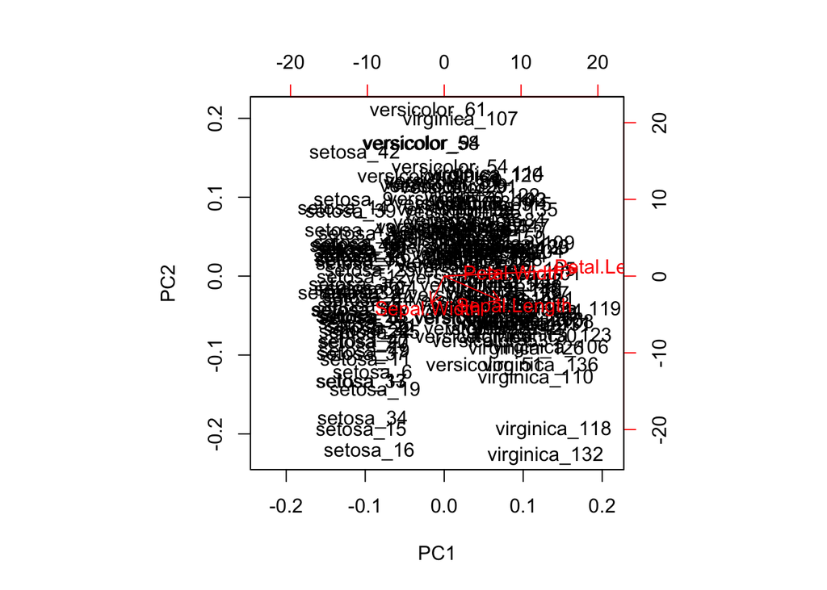

```r
biplot(pca_res2)
```

http://stats.stackexchange.com/questions/20101/what-is-the-difference-between-r-functions-prcomp-and-princomp

### 参考

- [difference between R functions prcomp and princomp](http://stats.stackexchange.com/questions/20101/what-is-the-difference-between-r-functions-prcomp-and-princomp)
- [Principal component analysis in R : prcomp() vs. princomp()](http://www.sthda.com/english/wiki/principal-component-analysis-in-r-prcomp-vs-princomp-r-software-and-data-mining)
- [how to get the contribution (%) of each parameter to PCA component](http://stackoverflow.com/questions/12760108/principal-components-analysis-how-to-get-the-contribution-of-each-paramete)
- [How to View Source Code in R](http://masterr.org/r/how-to-view-source-code-in-r/)
- [‘princomp’ can only be used with more units than variables](http://stackoverflow.com/questions/5686940/r-princomp-can-only-be-used-with-more-units-than-variables)